# Capstone Project, Bellabeat Casestudy

### **Observations from Analysis**

The statistical summary aided me to observe negative points in correspondence with the user health. Strategies has to be put in place to work on these observation so as to better the user health

**Activity dataset**

**Intensity dataset**

- Majority of these Users are lightly active
- Majority of these Users have a high sedentary time
- Majority of these Users posses lightly-active-distance

**Sleep dataset**

- Average sleep time of almost 7hours is observed
- A User slept for 796 mins(over 13hours) as recorded by Maximum Total Minutes Asleep
- A User was in bed for 961 mins(over 16hours) as recorded by Maximum Total Time in bed

### Merging Datasets

Activity dataset has columns that can be found in Calories and Intensity dataset thereby relating them. But columns in Sleep Dataset can’t be found in Activity dataset. So I will merge Activity and Sleep datasets together using OUTER JOIN because Activity dataset has 33 Users and Sleep dataset has 24 Users so as to have details of all 33 Users.

```r
Combined_data_outer <- merge(Sleep, Activity, by="Id", all = TRUE)
n_distinct(Combined_data_outer$Id)
```

```
## [1] 33
```

```r
head(Combined_data_outer)
```

```
##           Id       SleepDay TotalSleepRecords TotalMinutesAsleep TotalTimeInBed
## 1 1503960366 4/12/2016 0:00                 1                327            346
## 2 1503960366 4/12/2016 0:00                 1                327            346
## 3 1503960366 4/12/2016 0:00                 1                327            346
## 4 1503960366 4/12/2016 0:00                 1                327            346
## 5 1503960366 4/12/2016 0:00                 1                327            346
## 6 1503960366 4/12/2016 0:00                 1                327            346
##   ActivityDate TotalSteps TotalDistance TrackerDistance
## 1   2016-05-07      11992          7.71            7.71
## 2   2016-05-06      12159          8.03            8.03
## 3   2016-05-01      10602          6.81            6.81
## 4   2016-04-30      14673          9.25            9.25
## 5   2016-04-12      13162          8.50            8.50
## 6   2016-04-13      10735          6.97            6.97
##   LoggedActivitiesDistance VeryActiveDistance ModeratelyActiveDistance
```

[output cut: 20 more lines]

## **SHARE PHASE**

In this phase, i will visualize and show relationship between the data based on my analysis so far using the package “ggplot2” which has being loaded at the beginning of the project.

### Relationship between Total Steps and Sedentary Mintues

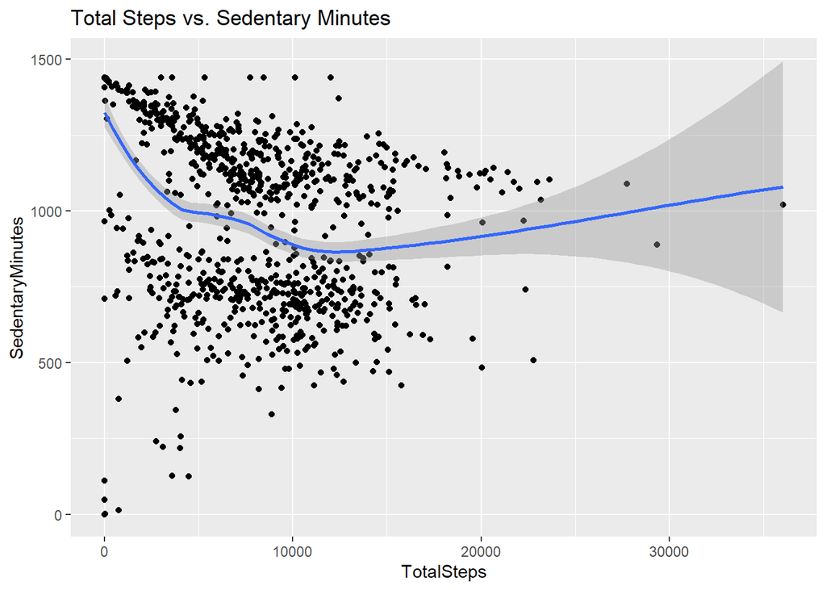

```r
ggplot(data=Activity) + geom_point(mapping = aes(x=TotalSteps, y=SedentaryMinutes)) + geom_smooth(mapping = aes(x=TotalSteps, y=SedentaryMinutes)) + labs(title="Total Steps vs. Sedentary Minutes")
```

```r
ggsave('Total_Steps_vs_Sedentary_Mintues_Chart.png')
```

### Relationship between Total Minutes Asleep and Total time in Bed

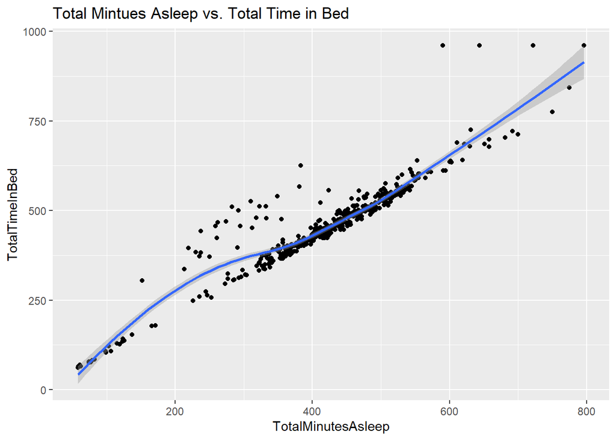

```r
ggplot(data=Sleep) + geom_point(mapping = aes(x=TotalMinutesAsleep, y=TotalTimeInBed)) + geom_smooth(mapping = aes(x=TotalMinutesAsleep, y=TotalTimeInBed)) + labs(title="Total Mintues Asleep vs. Total Time in Bed")
```

```r
ggsave('Total_Minutes_Asleep_vs_Total_time_in_Bed.png')
```

The chart above shows a positive linear relationship between Total Minutes Asleep and Total Time in Bed, i.e the higher the Total Minutes Asleep, the higher the Total Time in Bed.

### Relationship between Total Steps and Calories

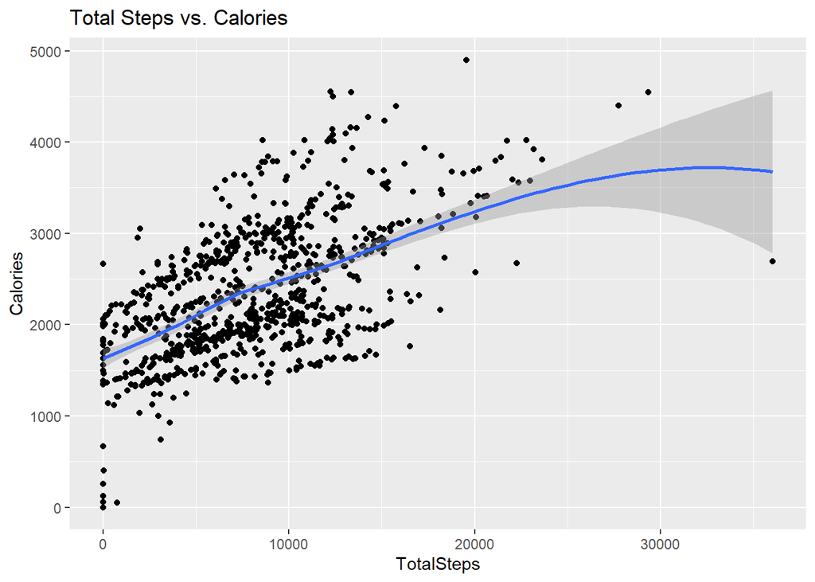

```r
ggplot(data=Activity) + geom_point(mapping = aes(x=TotalSteps, y=Calories)) + geom_smooth(mapping = aes(x=TotalSteps, y=Calories)) + labs(title="Total Steps vs. Calories")
```

```r
ggsave('Total_Steps_vs_Calories.png')
```

The chart above shows a positive relationship between Total Step and Calories, i.e the more steps taken, the more Calories are burnt.

### Relationship showing Active Intensity over Time

To visualize this, I will have to merge Intensity dataset with Weight dataset as a new dataframe “Intensity_over_time”using OUTER JOIN so as to access the time in Weight dataset

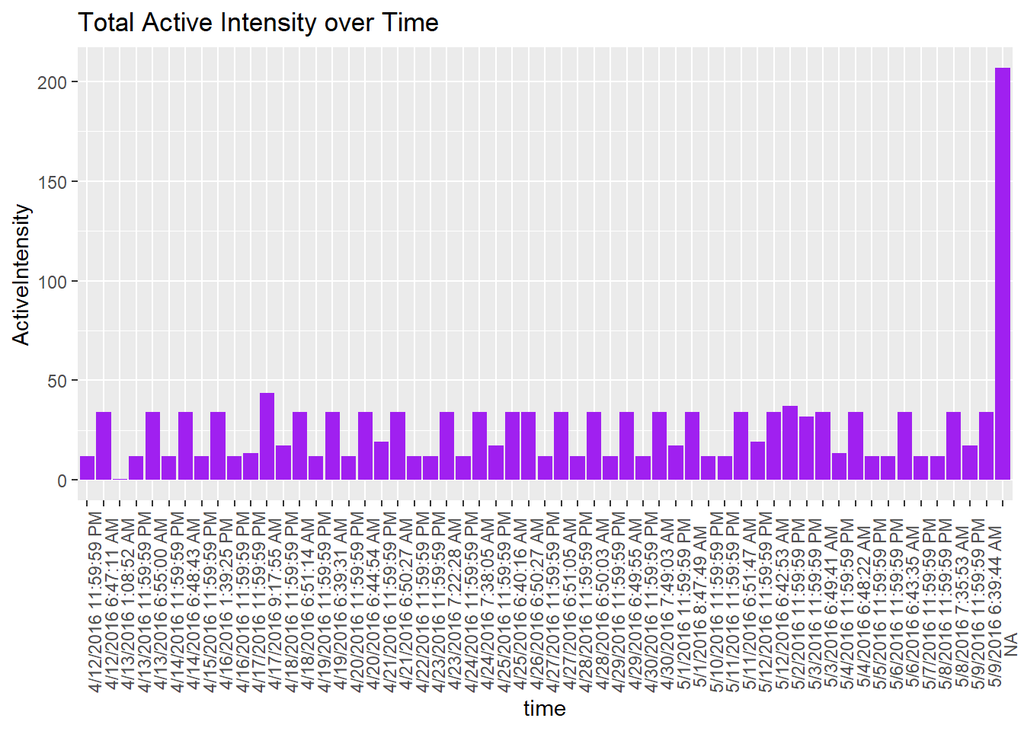

```r
Intensity$ActiveIntensity <- (Intensity$VeryActiveMinutes)/60

Intensity_over_time <- merge(Weight, Intensity, by="Id", all=TRUE)
Intensity_over_time$time <- format(Intensity_over_time$Date, format = "%H:%M:%S")

ggplot(data=Intensity_over_time, aes(x=time, y=ActiveIntensity)) + geom_histogram(stat = "identity", fill='purple') +
  theme(axis.text.x = element_text(angle = 90)) +
  labs(title="Total Active Intensity over Time ")
```

```r
ggsave('Intensity_over_time.png')
```

## **ACT PHASE**

In this phase, I will state my top insights based on my analysis and visualization

### Target Audience

The target audience of this analysis business tasks are women, who are busy with their daily activities and need to strike a balance between their work life and health using BellaBeat products.

### Recommendation to Marketing Team

1. **BellaBeat App should be redesigned to have an alarm/notification function which should be able to notify users periodically during the day to take a walk, thereby encouraging activeness and burning of calories**

Recommended steps according to Howdy Health,steps 7,000-10,000steps per day for adults aged 18-59years. 6,000-8,000steps per day for adults aged 60+years. 7,500steps per day for adults aged 62-101years.These steps could be achieved in bits during the day, say 4 notification per day, each notification aiming to acheive 2,000steps

- **BellaBeat App should be redesigned to have an alarm/notification function which should be able to notify users when to sleep, calculate the recommended sleep hours and also notify Users when to wake up so as to encourage a healthy sleeping habit.**

According to the National Sleep Foundation’s recommendations, adult aged 18 to 64years require 7-9hrs of sleep a night, while adults older than 64years require 7-8hrs of sleep.

3. **BellaBeat App should be redesigned to calculate and give feedback to User on their progress.**

These feedback should be weekly, which will encourage User to do better in the new week. These feedback should be in percentages. Total Recommended Steps per week should be 52,500steps so 26,250steps will be a 50% progress. Total Recommended Hours of sleep per week should be 56hrs so 45hrs should be 80% progress.Total Recommended Calories that should be burned by women per week 12,425 (as recommended by WebMD Fitness and Exercise is 1600-1950 per day, averagely 1775 ) so 8,000 should be 64%

4. **BellaBeat App should be redesigned to have an information section.**

This information section should be able to inform users on the benefits of healthy lifestyle, which includes taking walks, sleeping adequately, eating healthy which we help reduce calories in take.

5. **Intensity-over-time chart should be created so as to monitors users activity and constantly come up with strategy that will help keep BellaBeat in trend, unique and up-to-date.**

### References

This analysis was done with help of sample r codes and guidelines from the following site

- Coursera notes
- Case-study guidelines
- Case-study roadmap
- https://rmarkdown.rstudio.com
- https://www.geeksforgeeks.org
- https://cran.r-project.org